# stat04_tree_lab01

## 의사결정트리 실습

#### 위스콘 신 유방암 데이터 셋을 다운로드 받아, 세포특성의 조합으로

#### 악성을 정확하게 예측할 수 있는 분류 규칙을 만들어보자.

### 01. 데이터 불러오기

- 위스콘신 유방암 데이터 셋을 다운로드 받는다.

```r
loc <- "http://archive.ics.uci.edu/ml/machine-learning-databases/"
ds  <- "breast-cancer-wisconsin/breast-cancer-wisconsin.data"
url <- paste(loc, ds, sep="")
```

```r
breast <- read.table(url, sep=",", header=FALSE, na.strings="?")
names(breast) <- c("ID", "clumpThickness", "sizeUniformity",
                   "shapeUniformity", "maginalAdhesion",
                   "singleEpithelialCellSize", "bareNuclei",
                   "blandChromatin", "normalNucleoli", "mitosis", "class")
```

```r
head(breast)
```

| ID | clumpThickness | sizeUniformity | shapeUniformity | maginalAdhesion | singleEpithelialCellSize | bareNuclei | blandChromatin | normalNucleoli | mitosis | class |
| --- | --- | --- | --- | --- | --- | --- | --- | --- | --- | --- |
| 1000025 | 5 | 1 | 1 | 1 | 2 | 1 | 3 | 1 | 1 | 2 |
| 1002945 | 5 | 4 | 4 | 5 | 7 | 10 | 3 | 2 | 1 | 2 |
| 1015425 | 3 | 1 | 1 | 1 | 2 | 2 | 3 | 1 | 1 | 2 |
| 1016277 | 6 | 8 | 8 | 1 | 3 | 4 | 3 | 7 | 1 | 2 |
| 1017023 | 4 | 1 | 1 | 3 | 2 | 1 | 3 | 1 | 1 | 2 |
| 1017122 | 8 | 10 | 10 | 8 | 7 | 10 | 9 | 7 | 1 | 4 |

[figure not shown]

```r
table(breast$class)
```

```
  2   4
458 241
```

```r
df <- breast[-1]   ## ID 삭제

## class 범주형으로 변경
df$class <- factor(df$class, levels=c(2,4),
                   labels=c("benign", "malignant"))
str(df)
```

```
'data.frame':	699 obs. of  10 variables:
 $ clumpThickness          : int  5 5 3 6 4 8 1 2 2 4 ...
 $ sizeUniformity          : int  1 4 1 8 1 10 1 1 1 2 ...
 $ shapeUniformity         : int  1 4 1 8 1 10 1 2 1 1 ...
 $ maginalAdhesion         : int  1 5 1 1 3 8 1 1 1 1 ...
 $ singleEpithelialCellSize: int  2 7 2 3 2 7 2 2 2 2 ...
 $ bareNuclei              : int  1 10 2 4 1 10 10 1 1 1 ...
 $ blandChromatin          : int  3 3 3 3 3 9 3 3 1 2 ...
 $ normalNucleoli          : int  1 2 1 7 1 7 1 1 1 1 ...
 $ mitosis                 : int  1 1 1 1 1 1 1 1 5 1 ...
 $ class                   : Factor w/ 2 levels "benign","malignant": 1 1 1 1 1 2 1 1 1 1 ...
```

### 데이터 셋을 train과 validate 셋으로 분류 7:3

```r
set.seed(1234)
train <- sample(nrow(df), 0.7*nrow(df))
df.train <- df[train,]
df.validate <- df[-train,]
table(df.train$class)
table(df.validate$class)
```

```
   benign malignant
      329       160
```

```
   benign malignant
      129        81
```

### 01. 로지스틱 회귀 분석을 이용한 분류 및 예측

```r
fit.logit <- glm(class~., data=df.train, family=binomial())
summary(fit.logit)
```

```
Call:
glm(formula = class ~ ., family = binomial(), data = df.train)

Deviance Residuals:
     Min        1Q    Median        3Q       Max
-2.75813  -0.10602  -0.05679   0.01237   2.64317

Coefficients:
                          Estimate Std. Error z value Pr(>|z|)
(Intercept)              -10.42758    1.47602  -7.065 1.61e-12 ***
clumpThickness             0.52434    0.15950   3.287  0.00101 **
sizeUniformity            -0.04805    0.25706  -0.187  0.85171
shapeUniformity            0.42309    0.26775   1.580  0.11407
maginalAdhesion            0.29245    0.14690   1.991  0.04650 *
singleEpithelialCellSize   0.11053    0.17980   0.615  0.53871
bareNuclei                 0.33570    0.10715   3.133  0.00173 **
blandChromatin             0.42353    0.20673   2.049  0.04049 *
normalNucleoli             0.28888    0.13995   2.064  0.03900 *
mitosis                    0.69057    0.39829   1.734  0.08295 .
---
Signif. codes:  0 '***' 0.001 '**' 0.01 '*' 0.05 '.' 0.1 ' ' 1

(Dispersion parameter for binomial family taken to be 1)

    Null deviance: 612.063  on 482  degrees of freedom
Residual deviance:  71.346  on 473  degrees of freedom
  (6 observations deleted due to missingness)
AIC: 91.346

Number of Fisher Scoring iterations: 8
```

```r
prob <- predict(fit.logit, df.validate, type="response")  # 확률로 표시(0-1)
head(prob, 10)
```

**3**

0.00640288469976325

**4**

0.84142414618573

**5**

0.0137746805423031

**8**

0.00414566602617865

**14**

0.00314888118820102

**18**

0.00772185075503341

**19**

0.998271895956025

**20**

0.0217261101351983

**21**

0.998903362417598

**24**

<NA>

```r
pred <- factor(prob > .5, levels=c(FALSE, TRUE),
                     labels=c("benign", "malignant"))
logit.perf <- table(df.validate$class, pred,
                    dnn=c("Actual", "Predicted"))
logit.perf
```

```
           Predicted
Actual      benign malignant
  benign       118         2
  malignant      4        76
```

### tip. logit에서 step 함수 사용

```r
fit.logit <- glm(class~., data=df.train, family=binomial())
logit_step <- step(fit.logit)
logit_step
```

```
Start:  AIC=91.35
class ~ clumpThickness + sizeUniformity + shapeUniformity + maginalAdhesion +
    singleEpithelialCellSize + bareNuclei + blandChromatin +
    normalNucleoli + mitosis

                           Df Deviance     AIC
- sizeUniformity            1   71.380  89.380
- singleEpithelialCellSize  1   71.720  89.720
<none>                          71.346  91.346
- shapeUniformity           1   73.713  91.713
- mitosis                   1   74.578  92.578
- maginalAdhesion           1   75.289  93.289
- blandChromatin            1   75.860  93.860
- normalNucleoli            1   76.066  94.066
- bareNuclei                1   82.485 100.485
- clumpThickness            1   84.701 102.701

Step:  AIC=89.38
class ~ clumpThickness + shapeUniformity + maginalAdhesion +
    singleEpithelialCellSize + bareNuclei + blandChromatin +
    normalNucleoli + mitosis

                           Df Deviance     AIC
- singleEpithelialCellSize  1   71.727  87.727
<none>                          71.380  89.380
- mitosis                   1   74.588  90.588
- shapeUniformity           1   75.086  91.086
- maginalAdhesion           1   75.308  91.308
- blandChromatin            1   75.863  91.863
- normalNucleoli            1   76.166  92.166
- bareNuclei                1   82.511  98.511
- clumpThickness            1   85.112 101.112

Step:  AIC=87.73
class ~ clumpThickness + shapeUniformity + maginalAdhesion +
    bareNuclei + blandChromatin + normalNucleoli + mitosis

                  Df Deviance    AIC
<none>                 71.727 87.727
- mitosis          1   74.912 88.912
- shapeUniformity  1   76.248 90.248
- blandChromatin   1   76.712 90.712
- maginalAdhesion  1   76.778 90.778
- normalNucleoli   1   77.183 91.183
- bareNuclei       1   82.967 96.967
- clumpThickness   1   85.316 99.316
```

```
Call:  glm(formula = class ~ clumpThickness + shapeUniformity + maginalAdhesion +
    bareNuclei + blandChromatin + normalNucleoli + mitosis, family = binomial(),
    data = df.train)

Coefficients:
    (Intercept)   clumpThickness  shapeUniformity  maginalAdhesion
       -10.2455           0.5133           0.4303           0.3109
     bareNuclei   blandChromatin   normalNucleoli          mitosis
         0.3353           0.4392           0.3013           0.6796

Degrees of Freedom: 482 Total (i.e. Null);  475 Residual
  (6 observations deleted due to missingness)
Null Deviance:	    612.1
Residual Deviance: 71.73 	AIC: 87.73
```

### 02. 의사결정나무

- rpart 패키지 rpart() , prune() 함수 이용
- 데이터 마이닝의 가장 대중적인 기법

### 알고리즘

- 1. 결과 변수의 두 집단(악성, 양성)의 집단 순수성(동질성)이 극대화 되도록 가장 잘 분리하는 변수 선택
- 1. 두 집단을 분리하고 각 하위 그룹에 대해서도 이 절차를 반복
- 1. 하위집단이 관측치 최소수보다 적거나 비순수성을 줄이지 않을 때까지 단계 1,2를 반복
- 마지막 세트의 하위집단을 종착노드라 한다. 각 종착노드는 표본들의 결과의 최빈값(다수)에 기반하여
- 결과의 한 범주 혹은 다른 범주로 분류
- 1. 새로운 데이터에 대해 분류하기 위해 종착노드까지 나무를 타고 내려가 이것의 결과 최빈값을 부여함.

### rpart(formula, data=, method=,control=, na.action=na.rpart)

```
  formula : R에서의 모형 관련 공식
  data= 데이터 셋 이름(데이터 프레임)
  method="class", "anova"  ## 나무 모형의 종류를 지정
           (class: 범주, anova : 연속형(회귀) 기타 poisson, exp)
  control=옵션 파라미터
         =rpart.control(minsplit=30, cp=0.001)
  na.action = na.rpart     ##  목표변수가 결측치이면 전체 관측치를 삭제.
  split = 'information' or 'gini'
```

세부 설정 참조 : https://cran.r-project.org/web/packages/rpart/rpart.pdf

```r
library(rpart)
```

```r
set.seed(1234)         ## 샘플 패턴 지정
dtree <- rpart(class ~ ., data=df.train, method="class",
               parms=list(split="information"))
```

### 최종 나무의 크기를 정하기 위해 cptable 성분 확인

|  | CP | nsplit | rel error | xerror | xstd |
| --- | --- | --- | --- | --- | --- |
| 1 | 0.800000 | 0 | 1.00000 | 1.00000 | 0.06484605 |
| 2 | 0.046875 | 1 | 0.20000 | 0.30625 | 0.04150018 |
| 3 | 0.012500 | 3 | 0.10625 | 0.20625 | 0.03467089 |
| 4 | 0.010000 | 4 | 0.09375 | 0.18125 | 0.03264401 |

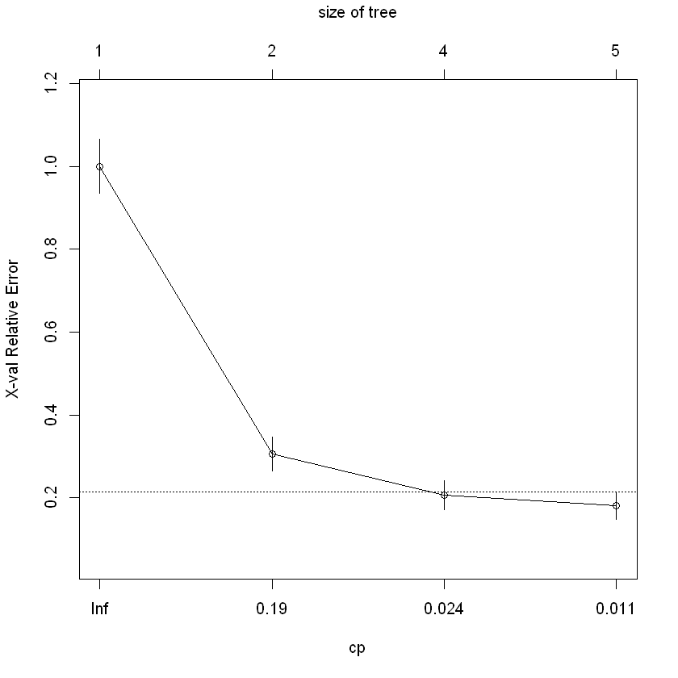

```r
dtree$cptable
plotcp(dtree)  # 복잡성 파리미터(Cp)에 대한 교차 검증 오류를 그린다.
```

- nsplit : n이면 n분기를 가진 나무는 n+1 종착노드를 갖는다.
- rel error : 나무에 대한 오류일
- xerror : 교차 검증 오류
- xstd : 교차 검증 오류의 표준 오차

  ```
       CP   nsplit  rel error   xerror  xstd
  1   0.800000    0   1.00000 1.00000 0.06484605
  2   0.046875    1   0.20000 0.30625 0.04150018
  ```

```r
dtree.pruned <- prune(dtree, cp=.0125)
```

```r
install.packages("rpart.plot")
```

```r
library(rpart.plot)
```

## prp

- type = 2 : 각 노드 밑에 분기 라벨을 그리기
- extra = 104 : 각 노드에서의 관측치 비율
- fallen.leaves = TRUE : 바닥의 종착 노드를 보이게 함.

```
           Predicted
Actual      benign malignant
  benign       122         7
  malignant      2        79
```

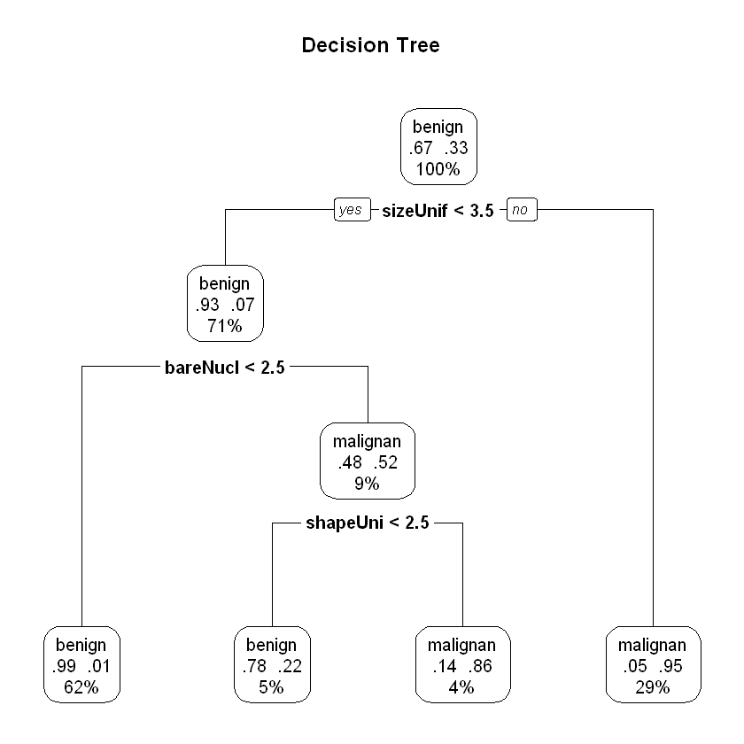

```r
prp(dtree.pruned, type = 2, extra = 104,
    fallen.leaves = TRUE, main="Decision Tree")

dtree.pred <- predict(dtree.pruned, df.validate, type="class")
dtree.perf <- table(df.validate$class, dtree.pred,
                    dnn=c("Actual", "Predicted"))
dtree.perf
```

### 2-2 조건적 추론 나무

- 변수와 분기가 순수성/동질성 척도보다는 유의성 검정에 기반하여 선택
- 유의성 검정은 순열검정

```
           Predicted
Actual      benign malignant
  benign       122         7
  malignant      3        78
```

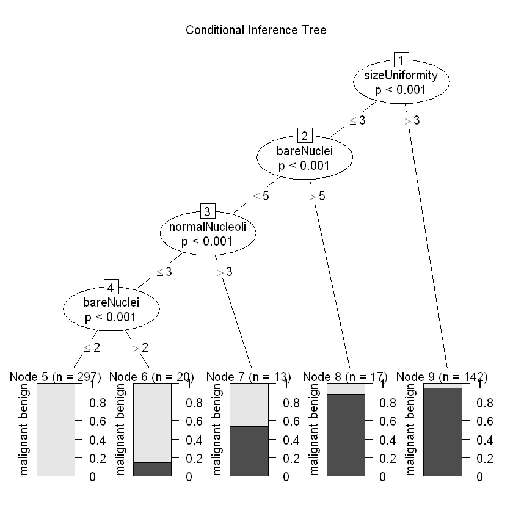

```r
library(party)
fit.ctree <- ctree(class~., data=df.train)
plot(fit.ctree, main="Conditional Inference Tree")

ctree.pred <- predict(fit.ctree, df.validate, type="response")
ctree.perf <- table(df.validate$class, ctree.pred,
                    dnn=c("Actual", "Predicted"))
ctree.perf
```

- 알고리즘
- step 1. 각 예측변수와 결과변수 간의 관계에 대한 p값을 계산
- step 2. 가장 낮은 p값을 가진 예측 변수를 선택
- step 3. 선택된 예측 변수와 종속변수에서 모든 가능한 이항 분기를 탐색(순열검정)가장 유의미한 분기를 선택
- step 4. 데이터를 두 집단으로 나눔. 각 하위 집단에 대해 위 프로세스를 계속 진행
- step 5. 분기가 더 이상 없을 때까지 계속함.